# On the dynamics of mark-ups, results section

Curtis Kephart and David Munro

# Summary Statistics

Summary of sessions and subjects.

| Number of Players | Subjects | Periods |
| --- | --- | --- |
| Four Players | 24 | 15 |
| Two Players | 16 | 15 |

Sessions were run at the Unversity of California Santa Cruz’ LEEPS Lab on February 8th and 9th 2017.

The experiment was conducted with oTree (*Citation: Chen, D.L., Schonger, M., Wickens, C., 2016. oTree - An open-source platform for laboratory, online and field experiments. Journal of Behavioral and Experimental Finance, vol 9: 88-97*) subjects were recruited with ORSEE (*Citation: Ben Greiner (2015), Subject Pool Recruitment Procedures: Organizing Experiments with ORSEE, Journal of the Economic Science Association 1 (1), 114-125. http://link.springer.com/article/10.1007/s40881-015-0004-4* )

## No data for Two-Player 0.25 Shopping Cost Treatment

# Hypothesis 1 - competitiveness and mark-ups

**Hypothesis 1**. *Static mark-ups will be lower in more competitive (higher N) markets.*

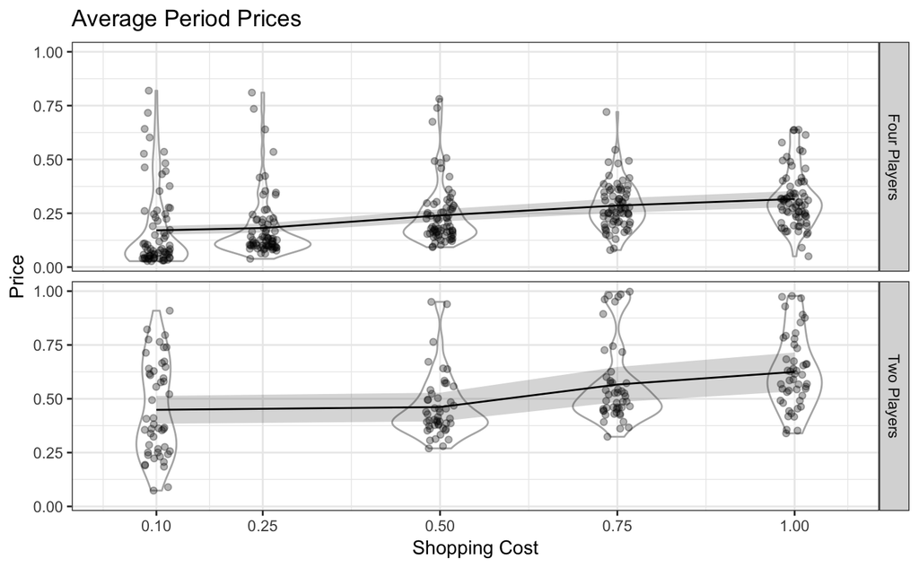

In the plot above,

- each dot is the average price per subject in one period (20 subperiods) with fixed shopping costs and player count.
- violins are similarly based on average player-period prices.
- the line is the average price for that player-number, shopping cost comvination,
- ribben is the confidence interval.
- A very similar plot appears when looking at all prices over all subperiods.

Comparing prices in both treatments.

|  | s = 0.1 | s = 0.25 | s = 0.5 | s = 0.75 | s = 1 |
| --- | --- | --- | --- | --- | --- |
| Four Players | 0.17 (±0.0201) | 0.18 (±0.0214) | 0.24 (±0.0283) | 0.29 (±0.0337) | 0.32 (±0.0373) |
| Two Players | 0.45 (±0.0648) | NA | 0.46 (±0.0666) | 0.57 (±0.0817) | 0.62 (±0.0902) |

Now, looking just at the later half of each period, subperiods 11 to 20, (remove from final)

|  | t = 0.1 | t = 0.25 | t = 0.5 | t = 0.75 | t = 1 |
| --- | --- | --- | --- | --- | --- |
| Four Players | 0.15 (±0.0176) | 0.14 (±0.0168) | 0.2 (±0.0238) | 0.25 (±0.0299) | 0.29 (±0.0344) |
| Two Players | 0.42 (±0.0605) | NA | 0.46 (±0.0665) | 0.56 (±0.0812) | 0.63 (±0.0906) |

Strong evidence for Hypothesis 1.

- Looking at the average prices within a period (all 20 subperiods) with the same player number and transport cost, there is a statistically significant difference between prices at each transport level between player number treatments.
- Even comparing `t = 1.0` in the four player game – the transport cost in which the four-player game had the highest prices – to `t = 0.1` in the two player game – in which prices were the lowest in the two-player game – the two player game has statistically significantly higher prices (p-value < 0.001).

```
    Welch Two Sample t-test

data:  player.price[(playerNum == "Two Players" & player.transport_cost ==  and player.price[(playerNum == "Four Players" & player.transport_cost ==     0.1)] and     1)]
t = 3.7618, df = 69.34, p-value = 0.0003491
alternative hypothesis: true difference in means is not equal to 0
95 percent confidence interval:
 0.06211334 0.20235194
sample estimates:
mean of x mean of y
0.4487187 0.3164861


    Wilcoxon rank sum test with continuity correction

data:  player.price[(playerNum == "Two Players" & player.transport_cost ==  and player.price[(playerNum == "Four Players" & player.transport_cost ==     0.1)] and     1)]
W = 2334, p-value = 0.00118
alternative hypothesis: true location shift is not equal to 0
```

# Hypothesis 2 - shipping costs and mark-ups

**Hypothesis 2**. *There is a positive relationship between shopping costs and mark-ups.*

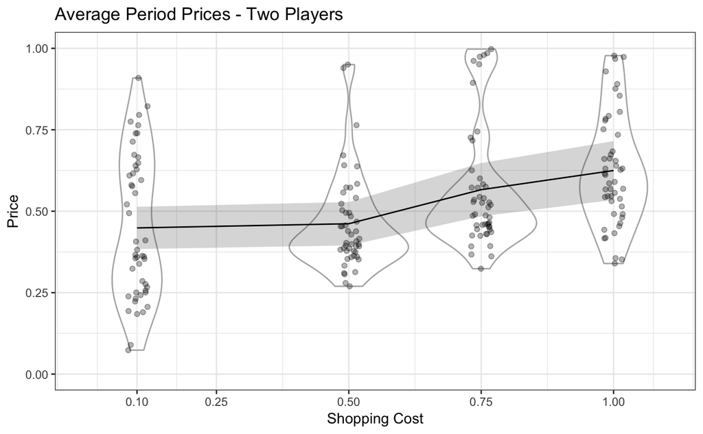

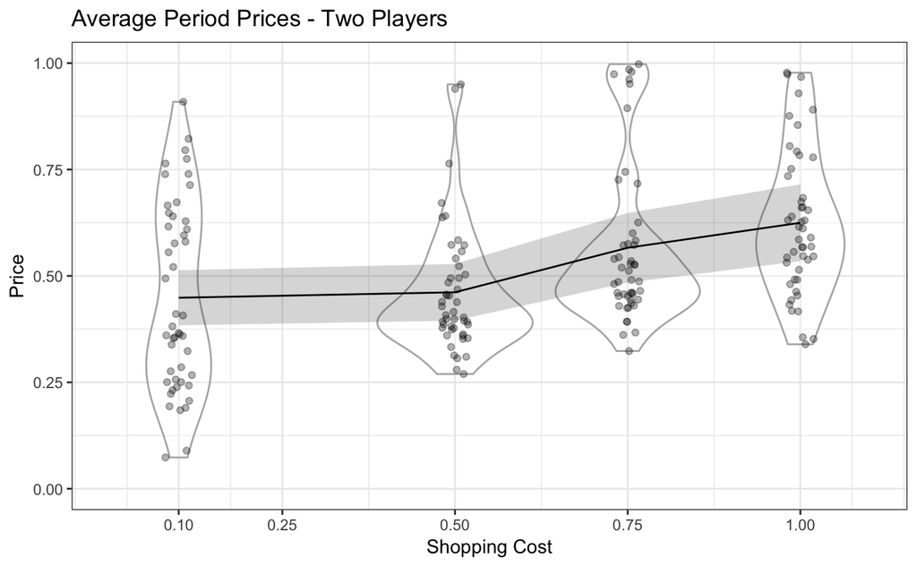

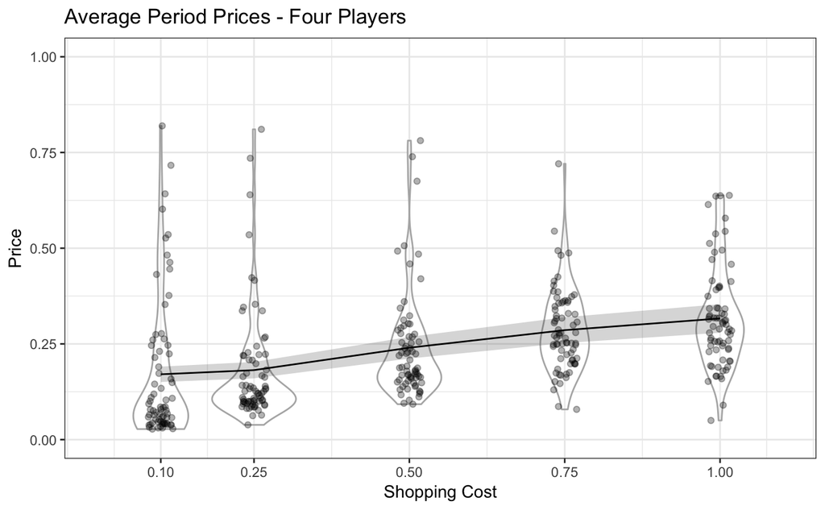

|  | Shopping Cost | N | Mean Price | Median Price | Standard Error |
| --- | --- | --- | --- | --- | --- |
| Four Players | 0.10 | 72 | 0.171 | 0.082 | 0.022 |
| Four Players | 0.25 | 72 | 0.182 | 0.126 | 0.018 |
| Four Players | 0.50 | 72 | 0.240 | 0.188 | 0.016 |
| Four Players | 0.75 | 72 | 0.286 | 0.269 | 0.013 |
| Four Players | 1.00 | 72 | 0.316 | 0.298 | 0.015 |
| Two Players | 0.10 | 48 | 0.449 | 0.374 | 0.032 |
| Two Players | 0.50 | 48 | 0.462 | 0.412 | 0.021 |
| Two Players | 0.75 | 48 | 0.566 | 0.501 | 0.027 |
| Two Players | 1.00 | 48 | 0.625 | 0.601 | 0.024 |

- `n` that’s each subject was exposed to 3 treatments of each shopping cost level. The two-player game had 16 subjects and the four-player had 24.

## Initial Look at Two-Player Game

First, within the two player game, comparing prices in `t = 0.1` and `t = 1.0` (see below), there is to be a statistically significant difference.

There is a relationship between prices and shopping cost treatments. In higher shopping cost settings subjects tended to have higher prices.

- Unit of observation is an individual’s average price within a period, at a set shopping cost level.
- A t test comparing prices between min and max shopping costs. Prices are average price at the session, participant, and period level. P-value 0.000029.
- A MW rank sum test comparing prices between min and max shopping costs. Prices are average price at the session, participant, and period level. P-value 0.0002061.

```
    Welch Two Sample t-test

data:  mean_price[player.transport_cost == 0.1] and mean_price[player.transport_cost == 1]
t = -4.4084, df = 88.447, p-value = 2.918e-05
alternative hypothesis: true difference in means is not equal to 0
95 percent confidence interval:
 -0.25562210 -0.09677373
sample estimates:
mean of x mean of y
0.4487187 0.6249167
```

```
cannot compute exact p-value with ties
```

```
    Wilcoxon rank sum test with continuity correction

data:  mean_price[player.transport_cost == 0.1] and mean_price[player.transport_cost == 1]
W = 645, p-value = 0.0002061
alternative hypothesis: true location shift is not equal to 0
```

## Initial Look at Four-Player Game

In the four-player game the relationship, at least between the lowest and highest shopping cost, appears stronger.

- A t test comparing prices between min and max shopping costs. Prices are average price at the session, participant, and period level. P-value 0.00000023.
- A MW rank sum test comparing prices between min and max shopping costs. Prices are average price at the session, participant, and period level. P-value < 0.000001

```
    Welch Two Sample t-test

data:  mean_price[player.transport_cost == 0.1] and mean_price[player.transport_cost == 1]
t = -5.4696, df = 127.71, p-value = 2.285e-07
alternative hypothesis: true difference in means is not equal to 0
95 percent confidence interval:
 -0.19866656 -0.09311122
sample estimates:
mean of x mean of y
0.1705972 0.3164861


    Wilcoxon rank sum test with continuity correction

data:  mean_price[player.transport_cost == 0.1] and mean_price[player.transport_cost == 1]
W = 1030.5, p-value = 4.458e-10
alternative hypothesis: true location shift is not equal to 0
```

## Model

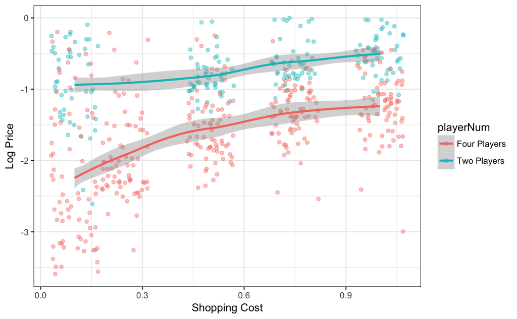

Here we have a log-log model regressing prices on shopping costs, with player-number fixed effects.

$ln(P_{ip}) = \beta_0 + \beta_1 \delta_{i} +\beta_2 ln(S_{ip}) + \beta_3 Period_p + \epsilon_{(ip)}$

```
Call:
lm(formula = log(price) ~ twoPlayer + log(player.transport_cost),
    data = df)

Residuals:
     Min       1Q   Median       3Q      Max
-1.66483 -0.32582 -0.05272  0.29873  1.93067

Coefficients:
                           Estimate Std. Error t value Pr(>|t|)
(Intercept)                -1.33090    0.03873  -34.36   <2e-16 ***
twoPlayer                   0.89671    0.04922   18.22   <2e-16 ***
log(player.transport_cost)  0.34693    0.02753   12.60   <2e-16 ***
---
Signif. codes:  0 ‘***’ 0.001 ‘**’ 0.01 ‘*’ 0.05 ‘.’ 0.1 ‘ ’ 1

Residual standard error: 0.5497 on 549 degrees of freedom
Multiple R-squared:  0.4873,    Adjusted R-squared:  0.4854
F-statistic: 260.9 on 2 and 549 DF,  p-value: < 2.2e-16
```

- Where $P_{ip}$ is the average price for for this participant in this period, the average of 20 sub-periods.
- $\delta_{i}$ is an indicator equal to 1 if individual $i$ participated in the two-player treatment.
- $S_ip$ is the shopping cost this individual faced in this period.
- where $Period_p$ is the period number.

# Hypothesis 3 - mark-up responsiveness to competition

**Hypothesis 3**. *Mark-ups will be less responsive to changes in shopping costs in less competitive (lower N) markets.*

$ln(Price_{(i,p)}) = \beta_0 + \beta_1 \delta_{2p} + \beta_2 ln(ShoppingCost) + \beta_3 \delta_{i} ln(ShoppingCost) + \epsilon_{(i,p)}$

```
Call:
lm(formula = log(price) ~ twoPlayer + log(player.transport_cost) +
    twoPlayer:log(player.transport_cost), data = df)

Residuals:
     Min       1Q   Median       3Q      Max
-1.76522 -0.32544 -0.03681  0.30700  2.07778

Coefficients:
                                     Estimate Std. Error t value Pr(>|t|)
(Intercept)                          -1.23051    0.04273 -28.800  < 2e-16 ***
twoPlayer                             0.65329    0.06791   9.620  < 2e-16 ***
log(player.transport_cost)            0.45442    0.03424  13.273  < 2e-16 ***
twoPlayer:log(player.transport_cost) -0.28173    0.05543  -5.083 5.11e-07 ***
---
Signif. codes:  0 ‘***’ 0.001 ‘**’ 0.01 ‘*’ 0.05 ‘.’ 0.1 ‘ ’ 1

Residual standard error: 0.5377 on 548 degrees of freedom
Multiple R-squared:  0.5104,    Adjusted R-squared:  0.5077
F-statistic: 190.4 on 3 and 548 DF,  p-value: < 2.2e-16
```

The coefficient $\beta_2$ estimates that a 1% increase in shopping costs will leave to a 0.45% increase in prices in the four-player game. The $\beta_3$ coefficient indicates *a one unit increase in shopping cost leads to a 28% decrease in prices in the two-player game relative to the 4-player game*“.

We have strong evidence that mark-ups are less responsive to tranpostation cost changes in the less competitive treatment than the more competitive treatment.

| Dependent Var: $ln(P_{ip})$ | Model 1 |  | Model 2 |  |
| --- | --- | --- | --- | --- |
| $\delta_{i}$ (two-player) | 0.897 | *** | 0.653 | *** |
|  | (0.049) |  | (0.068) |  |
| $ln(ShoppingCost)$ | 0.347 | *** | 0.454 | *** |
|  | (0.028) |  | (0.034) |  |
| $\delta_{i} \cdot ln(ShoppingCost)$ |  |  | -0.282 | *** |
|  |  |  | (0.055) |  |
| ————————————— | —— | — | —— | — |
| N | 552 |  | 552 |  |

# Hypothesis 4

**Hypothesis 4**. *Collusion will be easier to form in low shopping cost environments*

Define collusion

## Idea 1 - Joint positive profits.

A subject is said to be ‘colluding’ when they and their adjacent players have jointly positive profits. - In the save of the two-player game, both players’ profits are positive. In the case of the four-player game, the profits of the two players to the left and right (circle marketplace) are positive. - This poses of problem in comparing “collusion” between two and four-player games. So we should not do that.

|  | Shopping Cost | Percent of Period Joint Positive Profits | Period Group Obvservation |
| --- | --- | --- | --- |
| Two-Player | 0.10 | 0.2895833 | 15 |
| Two-Player | 0.50 | 0.7166667 | 15 |
| Two-Player | 0.75 | 0.8333333 | 15 |
| Two-Player | 1.00 | 0.8916667 | 15 |
| Four-Player | 0.10 | 0.2083333 | 9 |
| Four-Player | 0.25 | 0.3055556 | 9 |
| Four-Player | 0.50 | 0.3055556 | 9 |
| Four-Player | 0.75 | 0.3611111 | 9 |
| Four-Player | 1.00 | 0.5055556 | 9 |

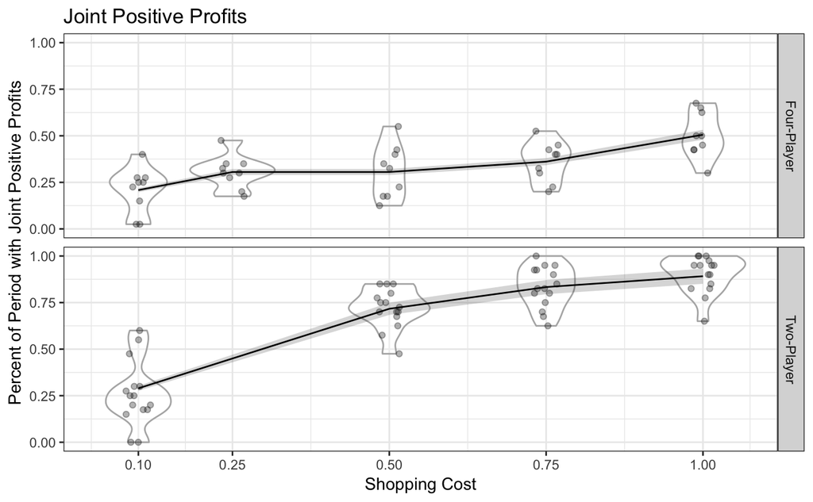

There is visually suggestive evidence that with higher shopping costs, groups are better able to collude.

## Idea 2 - Just look at profits.

Are profits higher? - Perhaps too linked to the discussion in Hypothesis 1-3.

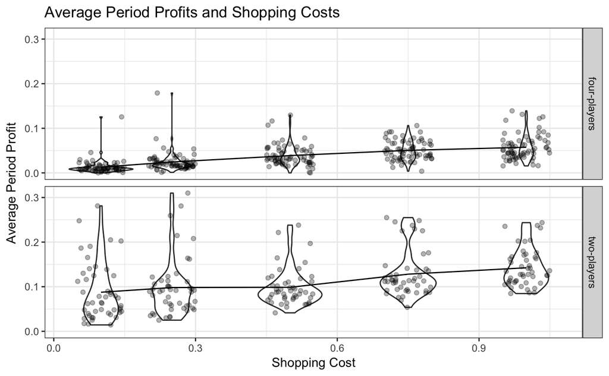

## to do for collusion

Tailing thing;

- get into more simple dynamics of collusion….

Compiled by Curtis Kephart, curtis.kephart@nyu.edu, with [R Markdown](http://rmarkdown.rstudio.com) Notebook.

2017-05-31 17:07:26 GMT, Asia/Dubai